# ST 558 Project 1 XML

Ariel Macari, Xiyou Zhou

# What is XML Data?

eXtensible Markup Language (XML) is a type of file used to store data. The stored data includes annotations to format the data but remins invisible to the user end. XML Data can be opened in a web browswer or any text editor. It is good use to store data like medical records, bank statements, and other data.

[XML Data Example](https://www.ibm.com/support/knowledgecenter/en/SSLTBW_2.3.0/com.ibm.zos.v2r3.ib6p000/ib6p9c4m2.htm)

# R Packages

The following lists the packages that were used in this analysis

- XML - This package is a collection of functions
- Tidyverse - The tidyverse is a system of packages that helps in read, clean, and present data. The tidyverse includes the following packages
  - ggplot2 - functions for creating graphics
  - ddplyr - functions for data manipulation
  - tidyr - functions to tidy data
  - readr- functions to read in files
  - purr - functions to work with functions and vectors
  - tibble - a data frame with better options
  - stringr - functions to help working with strings
  - forcasts - functions to help with factors in R
- DT - This package allows R data ojbects to be displayed as tables on HTML pages.
- matrixStats - This package include functions that apply to rows and columns of matrices (and vecotrs). This package was required for colIQRs.

# Data and Dataset

The data was found in the [DATA.GOV website](https://catalog.data.gov/dataset/age-adjusted-death-rates-for-the-top-10-leading-causes-of-death-united-states-2013)

The data was read by the following: * First, a reference to the website as an object called `health`. * Next, the xmL referenced was parsed into a structure referencing the xml tree with `xmlParse`. * Last the data was brought in a dataframe with the function `xmlToDataFrame`. The function requests that a list of the xmL nodes to be processed be included. The nodes resided in “//response//row//(the attribute)” for each column.  
* The columns were combined and the columns were named * The number of deaths and aadr as well as year were converted to numeric. * The following shows the code that was used to import the data into RStudio and the data.

```r
health<-(file = "http://data.cdc.gov/api/views/bi63-dtpu/rows.xml?accessType=DOWNLOAD")
xmldoc <- xmlParse(health)

year <- xmlToDataFrame(nodes = getNodeSet(xmldoc, "//response//row//year"))
cause_name <- xmlToDataFrame(nodes = getNodeSet(xmldoc, "//response//row//cause_name"))
state <- xmlToDataFrame(nodes = getNodeSet(xmldoc, "//response//row//state"))
deaths <- xmlToDataFrame(nodes = getNodeSet(xmldoc, "//response//row//deaths"))
aadr <- xmlToDataFrame(nodes = getNodeSet(xmldoc, "//response//row//aadr"))

HealthData<-(cbind(year, cause_name, state, deaths, aadr))
colnames(HealthData)<- (c("year", "cause_name", "state", "deaths", "aadr"))


#convert to numeric!
HealthData$deaths<-as.numeric(as.character(HealthData$deaths))
HealthData$aadr<-as.numeric(as.character(HealthData$aadr))
HealthData$year<-as.numeric(as.character(HealthData$year))

# show the data!
(datatable(HealthData))
```

|  | year | cause_name | state | deaths | aadr |
| --- | --- | --- | --- | --- | --- |
| 1 | 2012 | Kidney disease | Vermont | 21 | 2.6 |
| 2 | 2016 | Kidney disease | Vermont | 30 | 3.7 |
| 3 | 2013 | Kidney disease | Vermont | 30 | 3.8 |
| 4 | 2000 | Suicide | District of Columbia | 23 | 3.8 |
| 5 | 2014 | Kidney disease | Arizona | 325 | 4.1 |
| 6 | 2009 | Suicide | District of Columbia | 29 | 4.4 |
| 7 | 2011 | Kidney disease | South Dakota | 49 | 4.5 |
| 8 | 2015 | Kidney disease | Vermont | 39 | 4.5 |
| 9 | 2014 | Kidney disease | Vermont | 37 | 4.5 |
| 10 | 2013 | Kidney disease | Arizona | 374 | 4.9 |

[output cut: 10286 more lines]

- **The function (summary) was created to summarize the deaths and age adjusted death rate. There is a large discrepency within the groups**

```r
HealthData2<-tbl_df(HealthData)



apply(X = select(HealthData2, deaths:aadr), MARGIN = 2,
      FUN = summary, na.rm = TRUE)
```

```
##             deaths      aadr
## Min.         21.00    2.6000
## 1st Qu.     606.00   19.2000
## Median     1704.50   35.8000
## Mean      15367.93  128.0374
## 3rd Qu.    5678.00  153.0250
## Max.    2744248.00 1087.3000
```

- **Another function was created to list sd and IQR of death and age adjusted death(aadr). The results further show variation between the groups.**

```r
getsumary <-function(matx, ...) {

  if(!is.matrix(matx)) stop ("Wrong input type!")

  IQR <-colIQRs(matx,na.rm=T)
  #names(IQR) <- NULL

  sum<-colSums(matx,na.rm=T)
  mean<-colMeans(matx,na.rm=T)
  sd<-colSds(matx,na.rm=T)

  return (list(sum,mean,sd, IQR))
}
```

Description | Deaths , aadr

SD | 1.121456810^{5}, 224.381865  
IQR| 5072, 133.825

# Tables

- A contingency table showing that the dataset includes 18 years of the top 10 causes of death by state is shown below. The top 10 causes of death have remained the same throughout the years of 1999 - 2016. The following are the causes:
- All causes - The total number of deaths
- Alzheimer’s disease
- Cancer
- CLRD - Chronic Lower Respiratory Disease
- Diabetes
- Heart Disease
- Influenz and pneumonia
- kidney disease
- stroke
- suicide
- unintentional injury

Since the top 10 causes of death were aways the top 10, only the first 5 rows were printed.

```r
head(table(HealthData$state, HealthData$cause_name),n=5)
```

```
##
##              All causes Alzheimer's disease Cancer CLRD Diabetes
##   Alabama            18                  18     18   18       18
##   Alaska             18                  18     18   18       18
##   Arizona            18                  18     18   18       18
##   Arkansas           18                  18     18   18       18
##   California         18                  18     18   18       18
##
##              Heart disease Influenza and pneumonia Kidney disease Stroke
##   Alabama               18                      18             18     18
##   Alaska                18                      18             18     18
##   Arizona               18                      18             18     18
##   Arkansas              18                      18             18     18
##   California            18                      18             18     18
##
##              Suicide Unintentional injuries
##   Alabama         18                     18
##   Alaska          18                     18
##   Arizona         18                     18
##   Arkansas        18                     18
##   California      18                     18
```

# New Variable

A new variable `Death_Percent` was created to calculate the % of deaths attributed by each causes per year at the National and State levels. This new variable was helpful in understanding the impact for each cause by state and on the national level.

```r
US <-HealthData %>% filter(state =="United States") %>% group_by(cause_name) %>% arrange(cause_name,year) %>%  group_by(year) %>% mutate(totdeaths=max(deaths)) %>% mutate(Death_Percent = round(deaths/totdeaths*100,1) ) %>% filter(cause_name != c("All causes"))

State <-HealthData %>%  group_by(cause_name) %>% arrange(cause_name,year, state ) %>% group_by(year,state) %>% mutate(totdeaths=max(deaths)) %>% mutate(Death_Percent = round(deaths/totdeaths*100,1) )  %>% filter(cause_name != c("All causes"))
```

# Numeric Summary

The following shows the mean and standard deviation for % of deaths caussed by each cause.

```r
knitr::kable(US %>% group_by(cause_name) %>% summarise(Mean_Deaths =round(mean(Death_Percent),1), stdev_deaths =round(sd(Death_Percent),2), mean_aadr=(round(mean(aadr),1)), stdev_aadr=round(sd(aadr),2)))
```

| cause_name | Mean_Deaths | stdev_deaths | mean_aadr | stdev_aadr |
| --- | --- | --- | --- | --- |
| Alzheimer’s disease | 3.0 | 0.63 | 23.5 | 3.44 |
| Cancer | 22.8 | 0.40 | 178.4 | 14.43 |
| CLRD | 5.4 | 0.26 | 42.6 | 1.48 |
| Diabetes | 2.9 | 0.08 | 23.0 | 1.93 |
| Heart disease | 25.8 | 2.40 | 203.5 | 34.82 |
| Influenza and pneumonia | 2.3 | 0.28 | 18.4 | 3.53 |
| Kidney disease | 1.8 | 0.15 | 14.1 | 0.83 |
| Stroke | 5.8 | 0.73 | 45.7 | 9.21 |
| Suicide | 1.4 | 0.15 | 11.7 | 1.00 |
| Unintentional injuries | 4.8 | 0.46 | 39.0 | 2.92 |

```r
# calculated deaths by year and cause_name
A<-HealthData %>% filter(cause_name != c("All causes")) %>% select(year,cause_name,deaths) %>% arrange(year,cause_name)%>%
  group_by(year,cause_name) %>% summarise(totaldeath=sum(deaths))%>% spread(key = cause_name, value = totaldeath)

#calculate col means (average death by 18 years)
B<-colMeans(select(as.data.frame(A),2:11), na.rm = TRUE)

#bind role of A, B
c<-dplyr::bind_rows(A,B)
knitr::kable(c)
```

| year | Alzheimer’s disease | Cancer | CLRD | Diabetes | Heart disease | Influenza and pneumonia | Kidney disease | Stroke | Suicide | Unintentional injuries |
| --- | --- | --- | --- | --- | --- | --- | --- | --- | --- | --- |
| 1999 | 89072.0 | 1099676 | 248362.0 | 136798.0 | 1450384 | 127460 | 71050.00 | 334732.0 | 58398.00 | 195720.0 |
| 2000 | 99116.0 | 1106182 | 244018.0 | 138602.0 | 1421520 | 130626 | 74502.00 | 335322.0 | 58700.00 | 195800.0 |
| 2001 | 107704.0 | 1107536 | 246026.0 | 142744.0 | 1400284 | 124068 | 78960.00 | 327076.0 | 61244.00 | 203074.0 |
| 2002 | 117732.0 | 1114542 | 249632.0 | 146498.0 | 1393894 | 131362 | 81948.00 | 325344.0 | 63310.00 | 213484.0 |
| 2003 | 126914.0 | 1113804 | 252764.0 | 148438.0 | 1370178 | 130326 | 84906.00 | 315378.0 | 62968.00 | 218554.0 |
| 2004 | 131930.0 | 1107776 | 243974.0 | 146276.0 | 1304972 | 119328 | 84960.00 | 300148.0 | 64878.00 | 224024.0 |
| 2005 | 143198.0 | 1118624 | 261866.0 | 150238.0 | 1304182 | 126002 | 87802.00 | 287158.0 | 65274.00 | 235618.0 |
| 2006 | 144864.0 | 1119776 | 249166.0 | 144898.0 | 1263272 | 112652 | 90688.00 | 274238.0 | 66600.00 | 243198.0 |
| 2007 | 149264.0 | 1125750 | 255848.0 | 142764.0 | 1232134 | 105434 | 92896.00 | 271904.0 | 69196.00 | 247412.0 |
| 2008 | 164870.0 | 1130938 | 282180.0 | 141106.0 | 1233656 | 112568 | 96474.00 | 268296.0 | 72070.00 | 243804.0 |
| 2009 | 158006.0 | 1135256 | 274706.0 | 137410.0 | 1198826 | 107384 | 97870.00 | 257684.0 | 73818.00 | 236042.0 |
| 2010 | 166988.0 | 1149486 | 276160.0 | 138142.0 | 1195378 | 100194 | 100952.00 | 258952.0 | 76728.00 | 241718.0 |
| 2011 | 169948.0 | 1153382 | 285886.0 | 147662.0 | 1193154 | 107652 | 91182.00 | 257864.0 | 79036.00 | 252876.0 |
| 2012 | 167274.0 | 1165246 | 286978.0 | 147864.0 | 1199422 | 101272 | 91244.00 | 257092.0 | 81200.00 | 255584.0 |
| 2013 | 169534.0 | 1169762 | 298410.0 | 151156.0 | 1222210 | 113958 | 94224.00 | 257956.0 | 82298.00 | 261114.0 |
| 2014 | 187082.0 | 1183400 | 294202.0 | 152976.0 | 1228696 | 110454 | 96292.00 | 266206.0 | 85652.00 | 271856.0 |
| 2015 | 221122.0 | 1191860 | 310082.0 | 159070.0 | 1267684 | 114124 | 99918.00 | 280646.0 | 88386.00 | 293142.0 |
| 2016 | 232206.0 | 1196076 | 309192.0 | 160116.0 | 1270520 | 103074 | 100092.00 | 284284.0 | 89930.00 | 322748.0 |
| NA | 152601.3 | 1138282 | 270525.1 | 146264.3 | 1286131 | 115441 | 89775.56 | 286682.2 | 72204.78 | 241987.1 |

# Plot

A barplot for each cause by year is included below. The results show that Heart Disease and Cancer cause ~50% of the deaths in the US! The cause of deaths for heat disease is decreasing. However, the rate of deaths due to Althzheimers Disease is increasing !

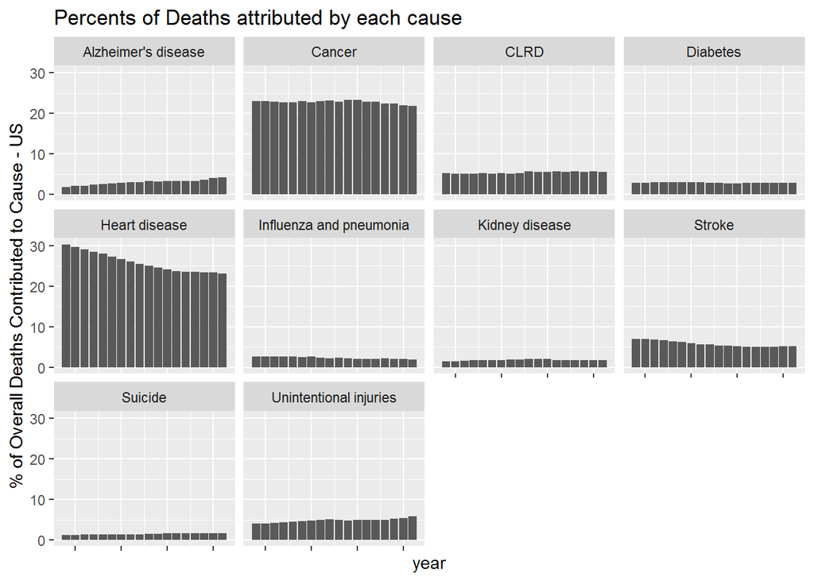

```r
ggplot(US, aes(x=year ,y=Death_Percent)) + geom_bar(stat="identity") + facet_wrap(aes(cause_name))  + theme(axis.text.x=element_blank())+ labs(title = "Percents of Deaths attributed by each cause")  +  ylab("% of Overall Deaths Contributed to Cause - US")
```

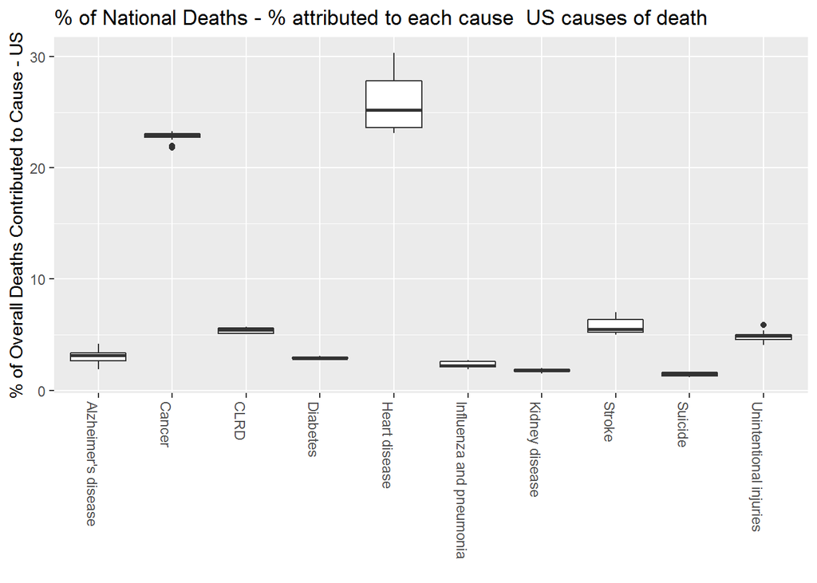

```r
ggplot(US, aes(x=cause_name ,y=Death_Percent)) + geom_boxplot() + theme(axis.text.x=element_text(angle = -90, hjust = 0)) +ylab("% of Overall Deaths Contributed to Cause - US") +  labs(title = "% of National Deaths - % attributed to each cause  US causes of death") + xlab("")
```

The first bar chart shows that most of the death percentages at the national level fall between one and seven percent based on the cause. This grouping of percentages has a bell shaped curve to them but the more intriguing bell shape is beyond the twenty percent threshold.

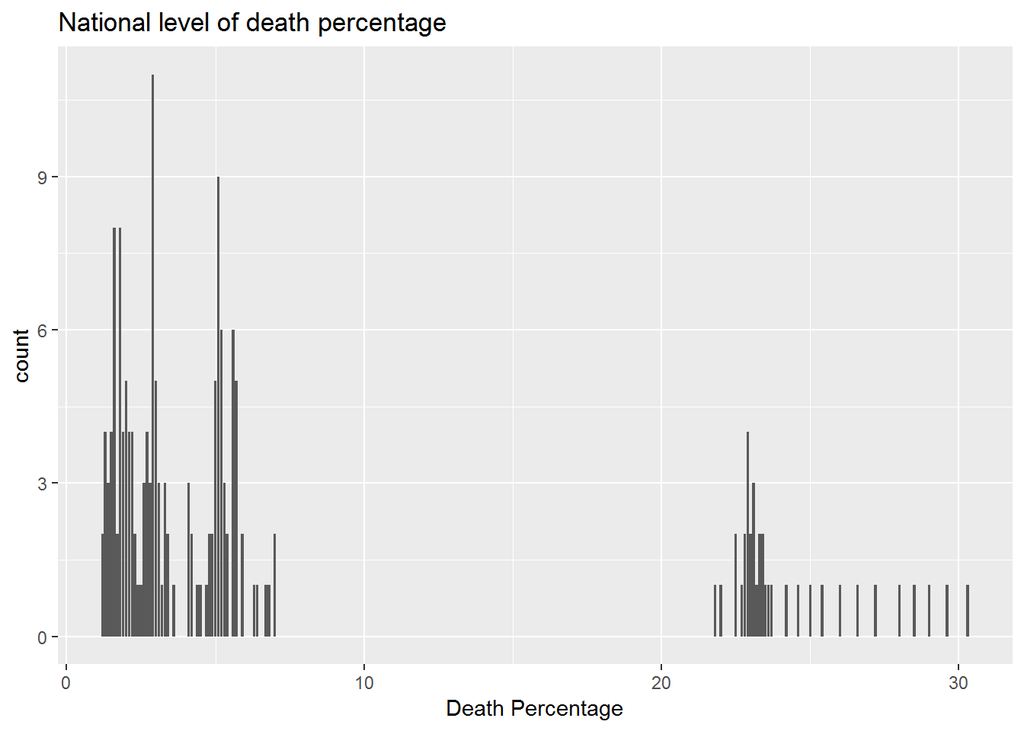

```r
gDeathPercUS <- ggplot(data = US, aes(x = Death_Percent))
gDeathPercUS + geom_bar() +
  labs(x = "Death Percentage", title = "National level of death percentage")
```

At the state level, the mational bar chart is reflected in chart below but with more refinement in the peaks and the outlying bell shape beyond twenty percent.

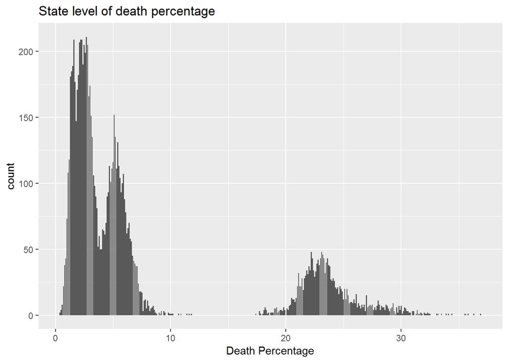

```r
gDeathPercState <- ggplot(data = State, aes(x = Death_Percent))
gDeathPercState + geom_bar() +
  labs(x = "Death Percentage", title = "State level of death percentage")
```

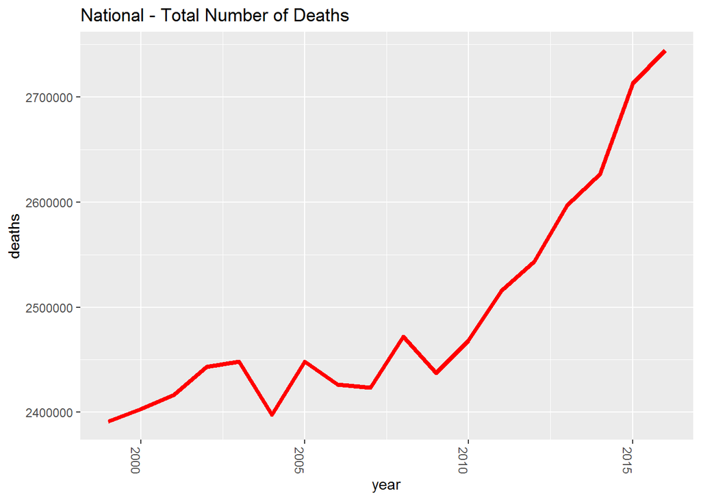

```r
Data<- HealthData %>% filter(state =="United States" & cause_name=="All causes") %>% select(year, deaths, aadr) %>% arrange(year)
ggplot(Data, aes(x=year, y = deaths, group=1))  + geom_line(lwd = 1.5, color = "red") + theme(axis.text.x=element_text(angle = -90, hjust = 0)) + labs(title = "National - Total Number of Deaths")
```

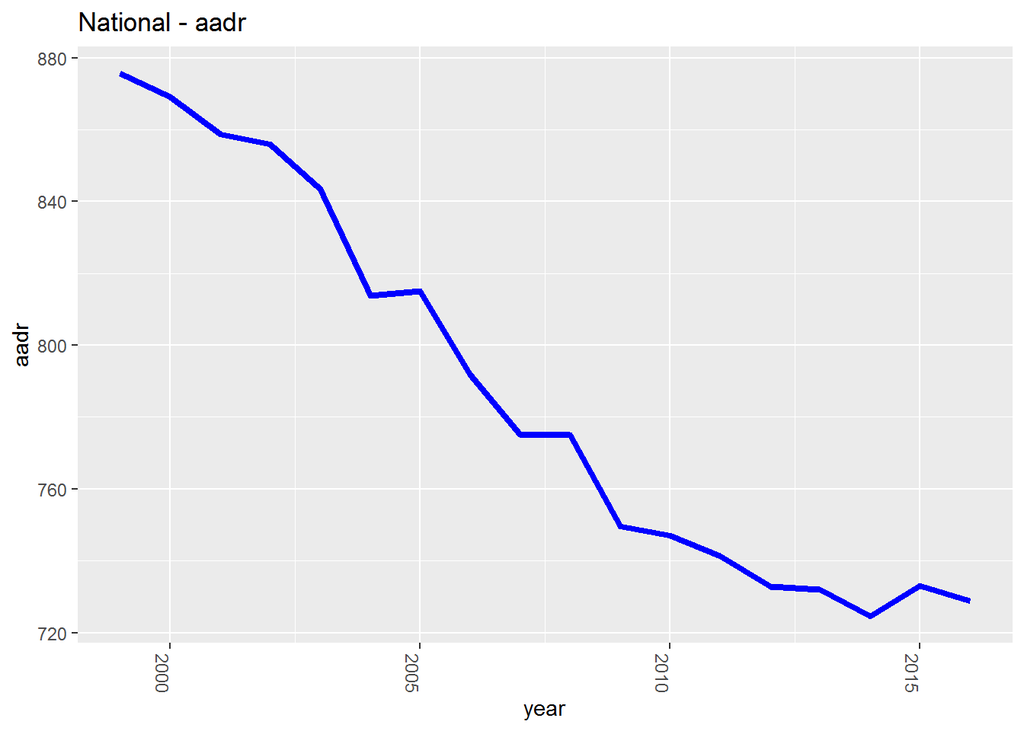

```r
ggplot(Data, aes(x=year, y = aadr, group=1))  + geom_line(lwd = 1.5, color = "blue") + theme(axis.text.x=element_text(angle = -90, hjust = 0)) + labs(title = "National - aadr")
```